# C09

Previous:Lecture 8 (While ) Next: Lecture 10 (Pointer)

Lecture 9 Algorithm Design

#### CSCI218 Engineering Programming (by Kebin Xu)

- Objective
- Searching algorithm
  - Linear search
  - Binary search
    - Example2
    - Divide and Conquer
    - binary search algorithm
  - Comparing algorithms
    - Example3

# Objective

- To understand the basic techniques for analyzing the efficiency of algorithms.
- To know what **searching** is and understand the **algorithms** for `linear` and `binary search`.
- To get general idea about divide and conquer
- To be able to calculate the `time complexity` of **linear search**, **binary search**using **Big-O notation**

# Searching algorithm

**Searching** is the process of looking for a particular value in a collection

back to top

## 1 Linear Search

### 1.1 Example1

Q: Write a function search(x, nums) -> pos, which accepts a number x and a array `nums`, if x is in the list, return the position of first occurrence, if not, return -1

```c
#include <stdio.h>
#include <assert.h>
int search(int x, int nums[], int size);//int search(int x, int num[])is not correc;
int main(){

    //for testing purpose
    int numbers[] = { 24, 1, 7, 8, 21, 30, 23, 7, 4, 19, 11, 5};
    int size = sizeof(numbers)/sizeof(int);
    assert(search(6, numbers, size)== -1);
    assert(search(7, numbers, size)==2);
    printf("pass!");
    //printf("found = %d", search(6, numbers, size));

    return 0;

}
int search(int x, int nums[], int size){
    int i;
    for (i = 0; i< size; i++){
        if (nums[i] == x){
            return i;
        }
    }
    return -1;

}
```

```
pass!
```

### 1.2 Linear search:

- The above algorith use the strategy called **linear search**, where you search through the array of items one by one until the target value is found.
- This algorithm wasn’t hard to develop, and works well for `modestly-sized` array
- If the collection of data is very `large`, it makes sense to organize the data somehow so that each data value doesn’t need to be examined.

back to top

## 2 Binary Search

### 2.1 Gussing game

- Write a loop that allows the user to make at most 5 guesses.
- For each guess, the game tells the user if the guess was "correct", "too high", or "too low."
- The game continues until the user guesses correctly or has guessed incorrectly 5 times.
- At the end of the game, one of the following messages is displayed: "You won in # guesses!" or "Sorry, you lose. The number was ##." where `##` is the "secret" number.

```c
#include <stdio.h>
#include <stdlib.h>
#include <time.h>

int main(){

    //srand(4);
    srand((int)time(0));
    int secret = rand()%20;
    int guessNum;
    int guess;

    printf("Enter a number between 0 and 20 inclusive:\n");
    scanf("%d", &guess);
    guessNum = 1;
    while (guessNum < 5 && guess != secret){
        if (guess > secret)
            printf("too high! ");
        if (guess < secret)
            printf("too low! ");
        printf("Enter a number between 0 and 20 inclusive:");
        scanf("%d", &guess);
        guessNum += 1;
    }
    if (guess == secret)
         printf("\nYou won in %d  guesses!", guessNum);
    else
       printf("\nsorry, you lose, the number was %d",secret);

    return 0;
}
```

```
Enter a number between 0 and 20 inclusive:
too high! Enter a number between 0 and 20 inclusive:too high! Enter a number between 0 and 20 inclusive:too high! Enter a number between 0 and 20 inclusive:too high! Enter a number between 0 and 20 inclusive:
sorry, you lose, the number was 9
```

### Note

- In the above example, the best guessing stategy is that each time we guess the middle of the remaining numbers to try to narrow down the range.
- This strategy is called **binary search**.
- Binary means two, and at each step we are dividing the remaining group of numbers into two parts.

back to top

## 2.2. Divide and conquer

The basic idea of the binary search algorithm was to successfully divide the problem in half. This technique is known as a **divide and conquer** approach.

- **Divide and conquer** divides the original problem into subproblems that are smaller versions of the original problem.
- In the binary search, the initial range is the entire list. We look at the middle element… if it is the target, we’re done. Otherwise, we continue by performing a binary search on either the top half or bottom half of the list.

## 2.3 Binary search algorithm

- While searching a target value in a list, if the data is **sorted** in ascending order (lowest to highest), we can skip checking some of the data.
- We can use `two variables` to keep track of the `endpoints` of the range in the sorted list where the number could be.
- Since the target could be anywhere in the list, initially `low` is set to the first location in the list, and `high` is set to the last

[figure not shown]

**find 19** in [1, 4, 4, 7, 7, 8, 11, 19, 21, 23, 24, 30]

[figure not shown]

**find 6** in [1, 4, 4, 7, 7, 8, 11, 19, 21, 23, 24, 30]

[figure not shown]

### binary search for sorted array

```c
#include <stdio.h>
#include <stdlib.h>

int binarySearch(int x, int *nums, int size);
int main(){
    int nums[] = { 1, 4, 4, 7, 7, 8, 11, 19, 21, 23, 24, 30};
    int size = sizeof(nums)/sizeof(int);
    int found = binarySearch(6, nums, size);
    printf("found = %d", found);
    return 0;
}

int binarySearch(int x, int nums[], int n){
    int mid, start = 0;
    int end = n -1;
    int item;
    //sentinel/stop condition  : start > end
    while (start <= end){ // There is still a range to search
        mid = (start + end)/2; // position of middle item
        item = nums[mid];
        if (x == item)        // Found it! Return the index
            return mid;
        else if (x < item)      // x is in lower half of range
            end = mid-1;     // move top marker down
        else               // x is in upper half
            start = mid + 1;   //     move bottom marker up
    }
    return -1;
}
```

```
found = -1
```

```c
//binary search algorithm with tracing
#include <stdio.h>
#include <stdlib.h>

int binarySearchTrace(int x, int *nums, int n);
int main(){
    //int nums[] = { 1, 4, 4, 7, 7, 8, 11, 19, 21, 23, 24, 30};
    int nums[] = { 1, 4, 4, 7, 7, 8, 11, 19, 21, 23, 24, 30, 33, 56, 89, 90};
    int size = sizeof(nums)/sizeof(int);
    int found = binarySearchTrace(-1, nums, size);
    printf("found position = %d", found);
    return 0;
}

int binarySearchTrace(int x, int *nums, int n){
    int mid, start = 0;
    int end = n -1;
    int item, count = 0;
    int found = -1;
    //sentinel : start > end
    while (start <= end){ // There is still a range to search
        count++;
        mid = (start + end)/2; // position of middle item
        printf("start = %d, end = %d, mid = %d, nums[%d] = %d\n",start, end, mid, mid,  nums[mid]);
        item = nums[mid];
        if (x == item){       // Found it! stop searching
            found = mid;
            break;
        }
        else if (x < item)      // x is in lower half of range
            end = mid-1;     // move top marker down
        else               // x is in upper half
            start = mid + 1;   //     move bottom marker up
    }
    printf("\nfound position = %d",found);
    printf("\nSearching '%d' need visit/compare %d items \n",x, count);
    return found;
}
```

```
start = 0, end = 15, mid = 7, nums[7] = 19
start = 0, end = 6, mid = 3, nums[3] = 7
start = 0, end = 2, mid = 1, nums[1] = 4
start = 0, end = 0, mid = 0, nums[0] = 1

found position = -1
Searching '-1' need visit/compare 4 items
found position = -1
```

back to top

## 3 Comparing Algorithms

- Which search algorithm is better, linear or binary?
  - The linear search is easier to understand and implement
  - The binary search is more efficient since it doesn’t need to look at each element in the list
- Linear search is generally faster for lists of length 10 or less
- There was little difference for lists of 10-1000
- Binary search is best for 1000+ (for one million list elements, binary search averaged .0003 seconds while linear search averaged 2.5 seconds)

While interesting, can we guarantee that these empirical results are not dependent on the `type of computer` they were conducted on, the amount of `memory` in the computer, the `speed` of the computer, etc.?

- In terms of measuring the efficiency of an algorithm, we can assume that the algorithm with the fewest number of “steps” is more efficient.
- How do we count the number of “steps”?
- Computer scientists attack these problems by analyzing the number of `steps` that an algorithm will take relative to the `size` or `difficulty` of the specific problem instance being solved.
- For searching, the difficulty is determined by the `size` of the collection – it takes more steps to find a number in a collection of a million numbers than it does in a collection of 10 numbers.
- How many steps are needed to find a value in a list of size `n`?

### 3.1 Linear Search

Let’s consider **linear search**.

- For a list of 10 items, the most work we might have to do is to look at each item in turn – looping at most 10 times.
- For a list twice as large, we would loop at most 20 times.
- For a list three times as large, we would loop at most 30 times!

The amount of `time` required is `linearly` related to the `size` of the list, `n`. This is what computer scientists call a **linear time algorithm**.

**Big O notation**: **O($n$)**

- Big O notation is used in Computer Science to describe the performance or **complexity of an algorithm**. Big O specifically describes the **worst-case** scenario, and can be used to describe the `execution time` required or the `space` used (e.g. in memory or on disk) by an algorithm.

### 3.2 Binary Search

Now, let’s consider **binary search**.

- Suppose the array has 16 items. Each time through the loop, half the items are removed because we narrow down the searching range by half
  - After one loop, 8 items remain.
  - After two loops, 4 items remain.
  - After three loops, 2 items remain
  - After four loops, 1 item remains.

[figure not shown]

[output not shown]

If a binary search loops `i` times, it can find a single value in a list of size $2^i$.

- To determine how many items (iteratons) are examined in a list of size `n`, we need to solve $n=2^i$ for i, or $i = \log_{2}n$.
- **Binary search** is an example of a `log time algorithm` – the amount of time it takes to solve one of these problems grows as the log of the problem size
- Computer scientists call this an **$\log_{2}n$** algorithm.
- **Big O notation**: **O($\log_{2}n$)**
  - This logarithmic property can be very powerful!

### 3.3 Example3

- Suppose you have the New York City phone book with 12 million names. You could walk up to a New Yorker and, assuming they are listed in the phone book, make them this proposition: “I’m going to try guessing your name. Each time I guess a name, you tell me if your name comes alphabetically before or after the name I guess.” How many guesses will you need?
- Our analysis shows us the answer to this question is $\log_{2}12000000$. We can guess the name of the New Yorker in 24 guesses! (how comes 24? )
  - 8 million < 12 million < 16 million
  - guessing a number in 16 million needs $\log_{2}16000000$
  - $2^{10}$ = 1024 , so 1000 needs 10 guesses
  - $2^{20}$ is about 1 million, so 1 million needs 20 guesses
  - 8 million is about $2^3$ * $2^{20}$ = $2^{23}$ needs 23 guesses
  - 16 million is about $2^4$ * $2^{20}$ = $2^{24}$ needs 24 guesses
- By comparison, using the **linear search** we would need to make, on average, 6,000,000 guesses!

[figure not shown]

Note:

- **Binary search** requires the data to be **sorted**
- If the data is unsorted, it must be sorted first!

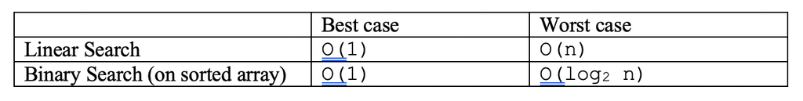